# Confirmatory Factor Analysis with a Small Sample

Juan C. Correa

2024-01-06

# Context

CFA is a well-known technique in psychology and social sciences. Despite its reputation, like any other technique, it also has its limitations. For example, in educational research, it is quite common to have small sample size (few observations) if they are collected through survey-based techniques such as scales or questionnaires. Our following case builds upon the context of a COIL experience where 65 students (i.e., 33 from Colombia and 32 from Ecuador) got together during six weeks for a two-hour-sessions per week using Google Classroom. Let’s open the data an conduct a standard Confirmatory Factor Analysis.

The data relates to 15 items (observed variables) which are theoretically linked to the concept of Transactive Memory System (TMS). TMS refers to the way people work in collaboration with others. Thus, TMS can be regarded as a “Collaboration Skill”. Here, we want to test the psychometric structure of the scale originally developed for English-speakers by Lewis (2003) and re-adapted for Spanish by García-Chitiva (2021).

## Testing Univariate and Multivariate Normal Distribution Assumptions

The evaluation of these assumptions is relatively straightforward through exploratory data visualization of kernel density plots and the Henze-Zirkler test implemented in the R package MVN

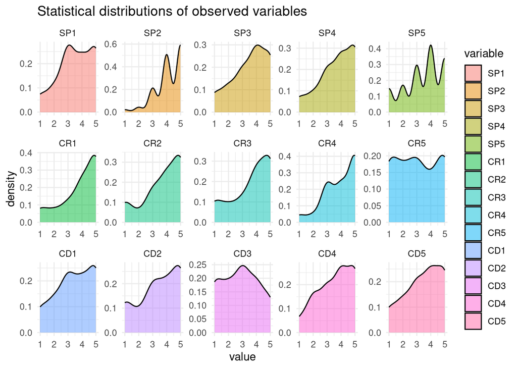

```
## $multivariateNormality
##            Test       HZ p value MVN
## 1 Henze-Zirkler 1.146849       0  NO
##
## $univariateNormality
##                Test  Variable Statistic   p value Normality
## 1  Anderson-Darling    SP1       2.6425  <0.001      NO
## 2  Anderson-Darling    SP2       4.8075  <0.001      NO
## 3  Anderson-Darling    SP3       2.8051  <0.001      NO
## 4  Anderson-Darling    SP4       3.1993  <0.001      NO
## 5  Anderson-Darling    SP5       2.6057  <0.001      NO
## 6  Anderson-Darling    CR1       5.1230  <0.001      NO
## 7  Anderson-Darling    CR2       4.1894  <0.001      NO
## 8  Anderson-Darling    CR3       4.2579  <0.001      NO
## 9  Anderson-Darling    CR4       4.3315  <0.001      NO
## 10 Anderson-Darling    CR5       2.8246  <0.001      NO
## 11 Anderson-Darling    CD1       2.5583  <0.001      NO
## 12 Anderson-Darling    CD2       3.1696  <0.001      NO
## 13 Anderson-Darling    CD3       2.0870  <0.001      NO
## 14 Anderson-Darling    CD4       2.7675  <0.001      NO
## 15 Anderson-Darling    CD5       2.5773  <0.001      NO
##
## $Descriptives
##      n     Mean   Std.Dev Median Min Max 25th 75th        Skew    Kurtosis
## SP1 65 3.553846 1.2378253      4   1   5    3    5 -0.43783261 -0.77860744
## SP2 65 4.169231 0.9112017      4   1   5    4    5 -1.06337598  0.95482009
## SP3 65 3.553846 1.2751320      4   1   5    3    5 -0.56353505 -0.77350691
## SP4 65 3.707692 1.2465337      4   1   5    3    5 -0.68443217 -0.54814357
## SP5 65 3.461538 1.2878874      4   1   5    3    4 -0.49962264 -0.84453847
## CR1 65 3.892308 1.3124771      4   1   5    3    5 -0.98873413 -0.23798724
## CR2 65 3.738462 1.3495013      4   1   5    3    5 -0.84124919 -0.47530792
## CR3 65 3.692308 1.3797993      4   1   5    3    5 -0.78262376 -0.70063989
## CR4 65 3.953846 1.1378539      4   1   5    3    5 -0.85132191 -0.07327122
## CR5 65 3.015385 1.5154651      3   1   5    2    5  0.02747577 -1.45291738
## CD1 65 3.446154 1.3349950      4   1   5    3    5 -0.37141430 -1.04945333
## CD2 65 3.476923 1.4154029      4   1   5    3    5 -0.50727979 -1.02579479
## CD3 65 2.861538 1.3448620      3   1   5    2    4  0.05853636 -1.19034460
## CD4 65 3.569231 1.2496153      4   1   5    3    5 -0.43877950 -0.96462795
## CD5 65 3.461538 1.3237839      4   1   5    3    5 -0.43558370 -0.99126936
```

## In-Depth Exploration Strategies

We will conduct our analyses by following two general strategies: “Bottom-up” and “Top-Down.” In the “Bottom-up” strategy, we will develop our measurement scale by testing each of its theoretical dimensions (one at time). In the “Top-Down” strategy we go the other way around.

## Bottom-up: Specialization Scale

Let’s see how our model should look like.

```
## lavaan 0.6.17 ended normally after 19 iterations
##
##   Estimator                                         ML
##   Optimization method                           NLMINB
##   Number of model parameters                        15
##
##   Number of observations                            65
##
## Model Test User Model:
##
##   Test statistic                                 2.691
##   Degrees of freedom                                 5
##   P-value (Chi-square)                           0.747
##
## Model Test Baseline Model:
##
##   Test statistic                               153.973
##   Degrees of freedom                                10
##   P-value                                        0.000
##
## User Model versus Baseline Model:
##
##   Comparative Fit Index (CFI)                    1.000
##   Tucker-Lewis Index (TLI)                       1.032
##
## Loglikelihood and Information Criteria:
##
##   Loglikelihood user model (H0)               -382.995
##   Loglikelihood unrestricted model (H1)       -381.649
##
##   Akaike (AIC)                                 795.990
##   Bayesian (BIC)                               828.605
##   Sample-size adjusted Bayesian (SABIC)        781.389
##
## Root Mean Square Error of Approximation:
##
##   RMSEA                                          0.000
##   90 Percent confidence interval - lower         0.000
##   90 Percent confidence interval - upper         0.121
##   P-value H_0: RMSEA <= 0.050                    0.807
```

[output cut: 22 more lines]

```
##                    Estimate  Std.Err  z-value  P(>|z|)
##    .SP1               0.000    0.123    0.000    1.000
##    .SP2              -0.000    0.123   -0.000    1.000
##    .SP3               0.000    0.123    0.000    1.000
##    .SP4              -0.000    0.123   -0.000    1.000
##    .SP5              -0.000    0.123   -0.000    1.000
##
## Variances:
##                    Estimate  Std.Err  z-value  P(>|z|)
##    .SP1  (VAR_SP1)    0.253    0.065    3.873    0.000
##    .SP2  (VAR_SP2)    0.978    0.172    5.698    0.000
##    .SP3  (VAR_SP3)    0.462    0.091    5.090    0.000
##    .SP4  (VAR_SP4)    0.133    0.059    2.256    0.024
##    .SP5  (VAR_SP5)    0.474    0.093    5.121    0.000
##     SP                1.000
```

```
## lavaan 0.6.17 ended normally after 19 iterations
##
##   Estimator                                         ML
##   Optimization method                           NLMINB
##   Number of model parameters                        15
##
##   Number of observations                            65
##
## Model Test User Model:
##                                               Standard      Scaled
##   Test Statistic                                 2.691       2.358
##   Degrees of freedom                                 5           5
##   P-value (Chi-square)                           0.747       0.798
##   Scaling correction factor                                  1.141
##     Satorra-Bentler correction
##
## Model Test Baseline Model:
##
##   Test statistic                               153.973     108.274
##   Degrees of freedom                                10          10
##   P-value                                        0.000       0.000
##   Scaling correction factor                                  1.422
##
## User Model versus Baseline Model:
##
##   Comparative Fit Index (CFI)                    1.000       1.000
##   Tucker-Lewis Index (TLI)                       1.032       1.054
##
##   Robust Comparative Fit Index (CFI)                         1.000
##   Robust Tucker-Lewis Index (TLI)                            1.043
##
## Loglikelihood and Information Criteria:
##
##   Loglikelihood user model (H0)               -382.995    -382.995
##   Loglikelihood unrestricted model (H1)       -381.649    -381.649
##
##   Akaike (AIC)                                 795.990     795.990
##   Bayesian (BIC)                               828.605     828.605
##   Sample-size adjusted Bayesian (SABIC)        781.389     781.389
##
```

[output cut: 34 more lines]

```
##                    Estimate  Std.Err  z-value  P(>|z|)
##    .SP1               0.000    0.123    0.000    1.000
##    .SP2              -0.000    0.123   -0.000    1.000
##    .SP3               0.000    0.123    0.000    1.000
##    .SP4              -0.000    0.123   -0.000    1.000
##    .SP5              -0.000    0.123   -0.000    1.000
##
## Variances:
##                    Estimate  Std.Err  z-value  P(>|z|)
##    .SP1  (VAR_SP1)    0.253    0.069    3.678    0.000
##    .SP2  (VAR_SP2)    0.978    0.197    4.959    0.000
##    .SP3  (VAR_SP3)    0.462    0.160    2.890    0.004
##    .SP4  (VAR_SP4)    0.133    0.063    2.129    0.033
##    .SP5  (VAR_SP5)    0.474    0.125    3.798    0.000
##     SP                1.000
```

```
## Model Test User Model:
##
##   Test statistic                                 2.691
##   Degrees of freedom                                 5
##   P-value (Chi-square)                           0.747
##
##   Browne's residual-based (ADF) test
##   Test statistic                                 3.066
##   Degrees of freedom                                 5
##   P-value (Chi-square)                           0.690
```

```
## Model Test User Model:
##
##   Test statistic                                 2.691
##   Degrees of freedom                                 5
##   P-value (Chi-square)                           0.747
##
##   Browne's residual-based (ADF) test
##   Test statistic                                 3.066
##   Degrees of freedom                                 5
##   P-value (Chi-square)                           0.690
```

|  | Fit.Index | ModelA | ModelB |
| --- | --- | --- | --- |
| chisq | Chi2 | 2.691 | 2.358 |
| cfi | CFI | 1.000 | 1.000 |
| tli | TLI | 1.032 | 1.043 |
| rmsea | RMSEA | 0.000 | 0.000 |
| srmr | SRMR | 0.020 | 0.020 |
| aic | AIC | 795.990 | 795.990 |
| bic | BIC | 828.605 | 828.605 |